# Data Analysis_HB_11052016

Hendrik Bruns

11052016

# Descriptive Statistics

Following are relevant aggregated statistics and statistics by each of the 11 treatments for each of three relevant dependent variables. These relevant dependent variables are 1. Donation, which is the amount the subject donated in order to retire emission rights 2. Donated, which is equal to 1 if the subject donated a positive amount, and 0 otherwise 3. Belief, which is the amount the subject thinks other participants in this experiment donated on average (not incentivized)

## 1. Variable: Donation to retire carbon licenses

### Aggregated descriptive statistics

```
##    Min. 1st Qu.  Median    Mean 3rd Qu.    Max.
##   0.000   0.000   1.000   1.442   2.000   7.000
```

```
## [1] 1.544451
```

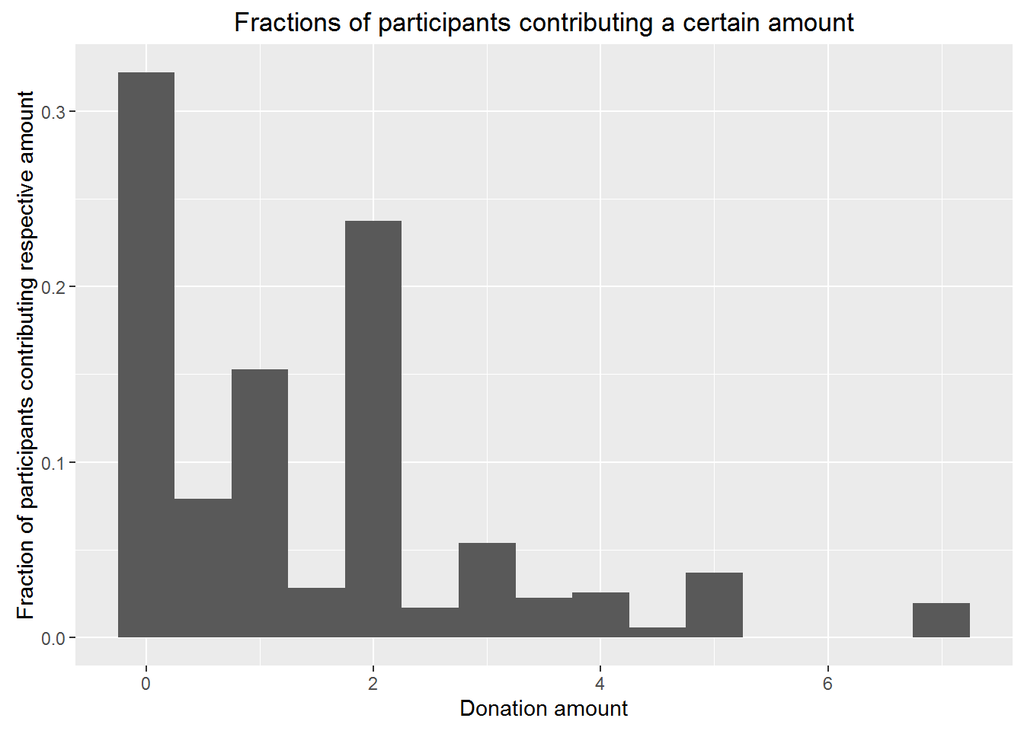

*30.79% of the participants donate nothing. 15.25 donate 1â¬, 23.73% donate 2â¬,*

### Distribution of aggregated donations

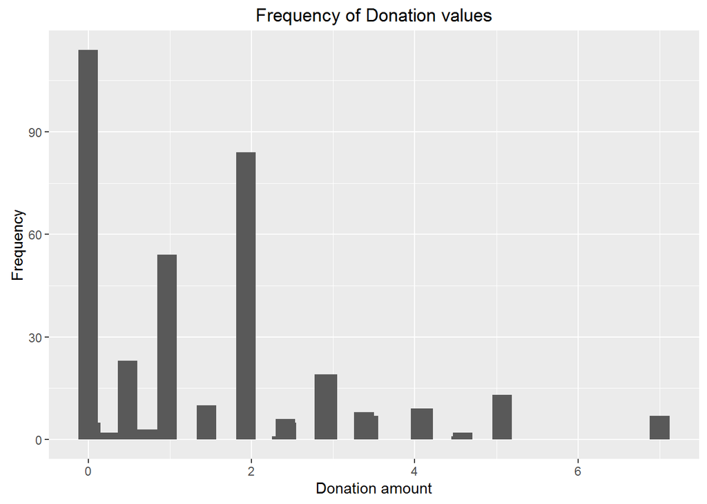

### Distribution of aggregated donations with normal curve

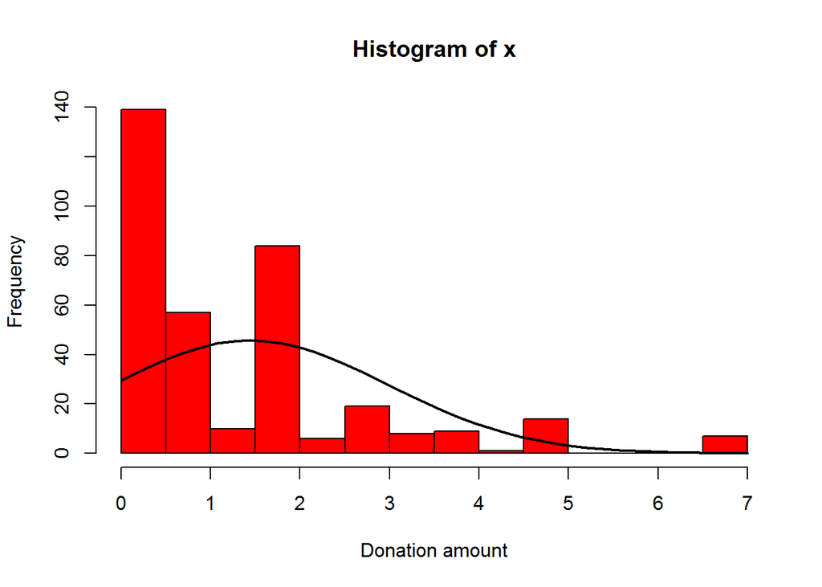

### Kernel density plot of aggregated donations

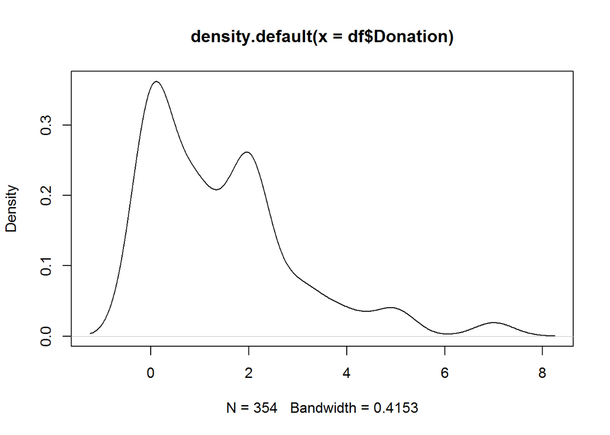

#### Distribution of donations by treatment

```
## group: Control
##   vars  n mean   sd median trimmed  mad min max range skew kurtosis   se
## 1    1 31 1.13 1.15      1    1.02 1.48   0   4     4 0.42    -0.94 0.21
## --------------------------------------------------------
## group: RecNos
##   vars  n mean   sd median trimmed  mad min max range skew kurtosis   se
## 1    1 31 1.24 1.39      1    0.99 1.48   0   5     5 1.14     0.52 0.25
## --------------------------------------------------------
## group: DefNos
##   vars  n mean   sd median trimmed  mad min max range skew kurtosis   se
## 1    1 34 1.42 2.08    0.5    1.05 0.74   0   7     7 1.46     0.93 0.36
## --------------------------------------------------------
## group: RecNap
##   vars  n mean   sd median trimmed  mad min max range skew kurtosis   se
## 1    1 33 1.32 1.31      1    1.15 1.48   0   5     5 0.83     0.13 0.23
## --------------------------------------------------------
## group: DefNap
##   vars  n mean   sd median trimmed  mad min max range skew kurtosis  se
## 1    1 33 1.38 1.13    1.5    1.29 1.19   0   4     4 0.27    -0.88 0.2
## --------------------------------------------------------
## group: RecPol
##   vars  n mean   sd median trimmed  mad min max range skew kurtosis   se
## 1    1 32  1.6 1.29   1.75    1.53 1.85   0   5     5 0.43    -0.48 0.23
## --------------------------------------------------------
## group: DefPol
##   vars  n mean   sd median trimmed  mad min max range skew kurtosis   se
## 1    1 29 1.66 1.68      1    1.44 1.48   0   7     7 1.51     1.87 0.31
## --------------------------------------------------------
## group: RecPar
##   vars  n mean   sd median trimmed  mad min max range skew kurtosis  se
## 1    1 30 1.68 1.65      1    1.48 1.48   0   7     7 1.13     1.32 0.3
## --------------------------------------------------------
## group: DefPar
##   vars  n mean   sd median trimmed  mad min max range skew kurtosis   se
## 1    1 34 1.66 1.89      1    1.34 1.48   0   7     7 1.46     1.49 0.32
## --------------------------------------------------------
## group: RecKno
##   vars  n mean   sd median trimmed  mad min max range skew kurtosis   se
## 1    1 33 1.18 1.47      1    0.91 1.48   0   7     7 2.06     5.17 0.26
## --------------------------------------------------------
## group: DefKno
##   vars  n mean  sd median trimmed  mad min max range skew kurtosis   se
## 1    1 34 1.59 1.7    1.5     1.4 2.22   0   5     5 0.73    -0.74 0.29
```

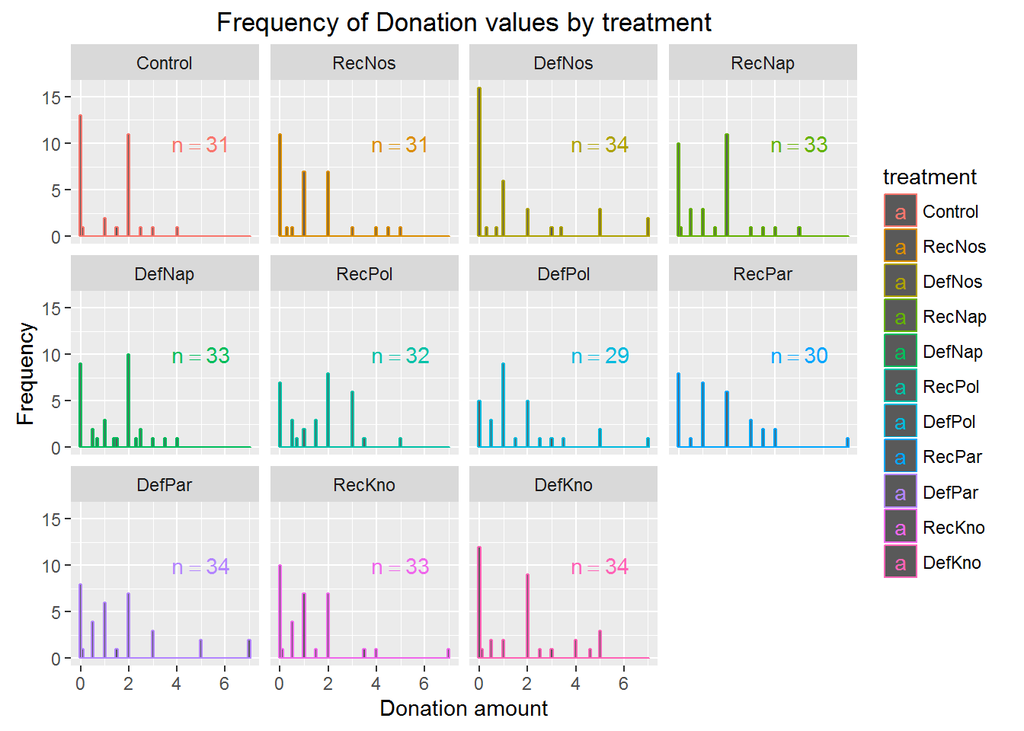

### Donations by treatment (Boxplot)

*Red diamonds in boxplots represent the respective means*

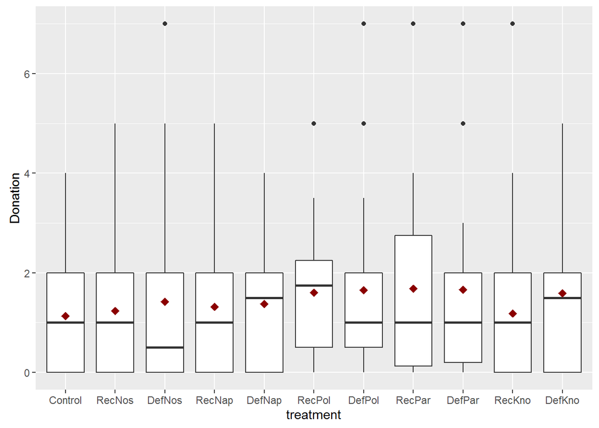

### Donations by aggregated treatment (Boxplot), i.e. Def vs. Rec vs. Control

```r
describeBy(df$Donation, df$RecvsDef)
```

```
## group: Rec
##   vars   n mean   sd median trimmed  mad min max range skew kurtosis   se
## 1    1 159  1.4 1.42      1     1.2 1.48   0   7     7 1.24     1.89 0.11
## --------------------------------------------------------
## group: Def
##   vars   n mean   sd median trimmed  mad min max range skew kurtosis   se
## 1    1 164 1.54 1.71      1    1.23 1.48   0   7     7 1.38     1.56 0.13
## --------------------------------------------------------
## group: Control
##   vars  n mean   sd median trimmed  mad min max range skew kurtosis   se
## 1    1 31 1.13 1.15      1    1.02 1.48   0   4     4 0.42    -0.94 0.21
```

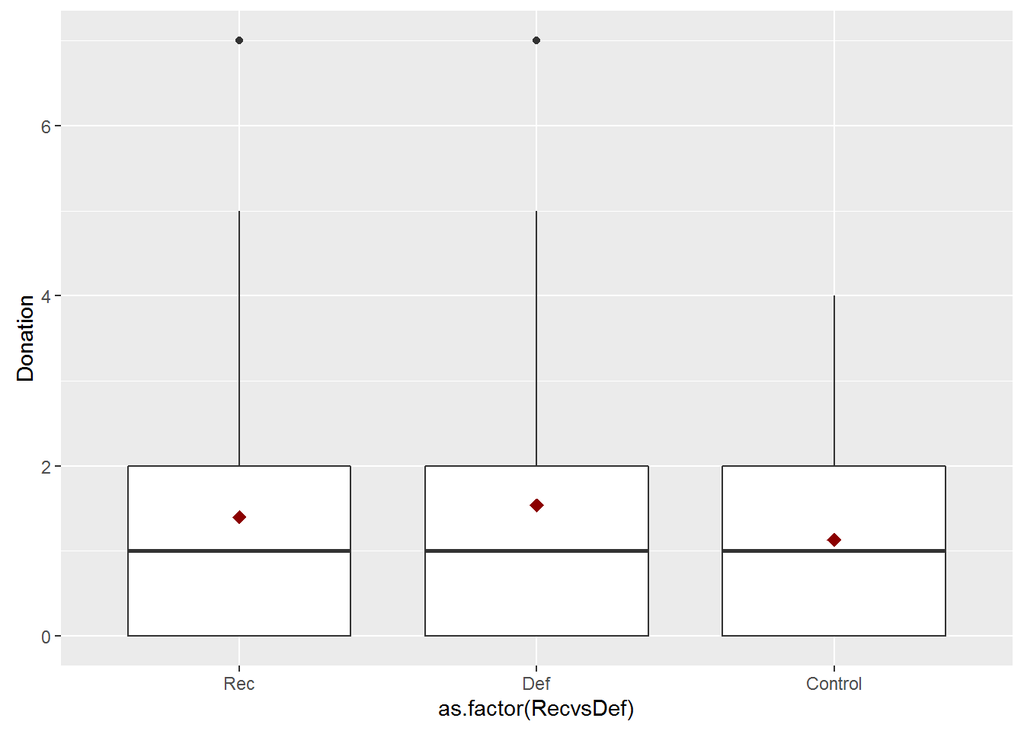

### Donations by Reactance score

The reactance score was constructed by changing each of the 11 rectance-items to a dummy variable equal to 1 if the subject chose 3 or 4 on the respective item, and 0 otherwise. Afterwards, all 11 dummies were added to construct an ordinal Reactance score.

Shows a point plot (not jittered) with Donation amount and the respective Reactance score of each participant. Includes a linear regression line, including the 95% confidence region, of the Reactance score as a predictor for the Donation amount.

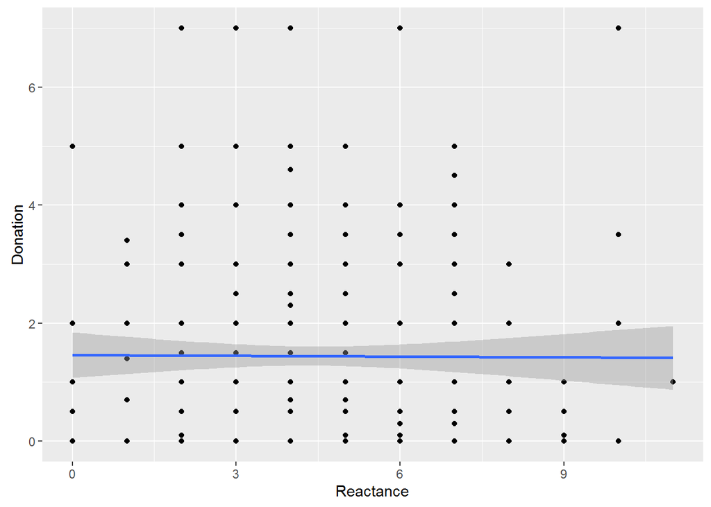

*To see how often combinations of Reactance and Donation scores appeared*

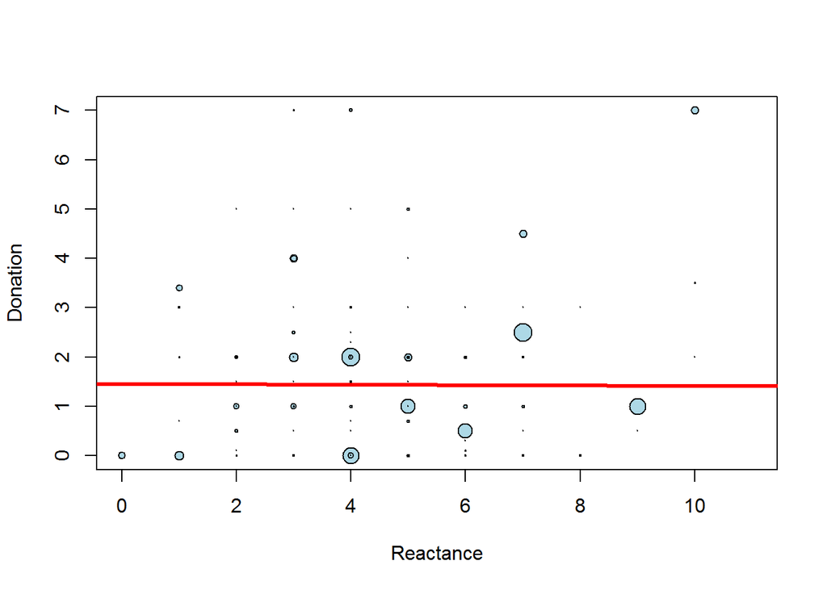

#### Donations by Reactance score per treatment

Shows a point plot (not jittered) with Donation amount and the respective Reactance score of each participant, for each treatment. Includes a linear regression line, including the 95% confidence region, of the Reactance score as a predictor for the Donation amount, for each treatment.

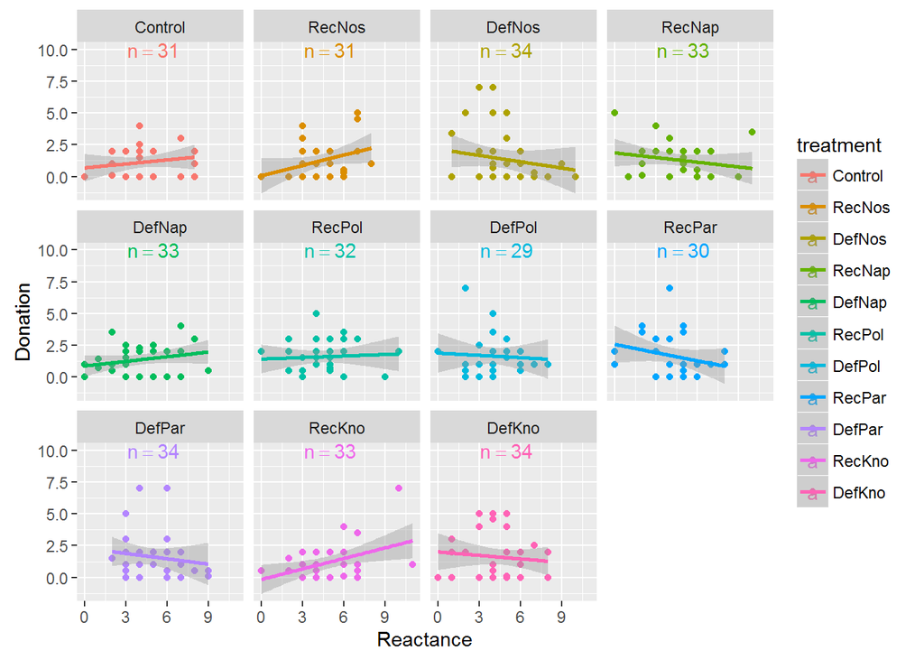

### Donations by EAI score

The EAI score was constructed by changing each of the 12 EAI-items to a dummy variable equal to 1 if the subject chose 3 or 4 on the respective item, and 0 otherwise. Afterwards, all 12 dummies were added to construct an ordinal EAI score.

Shows a point plot (not jittered) with Donation amount and the respective EAI score of each participant. Includes a linear regression line, including the 95% confidence region, of the EAI score as a predictor for the Donation amount.

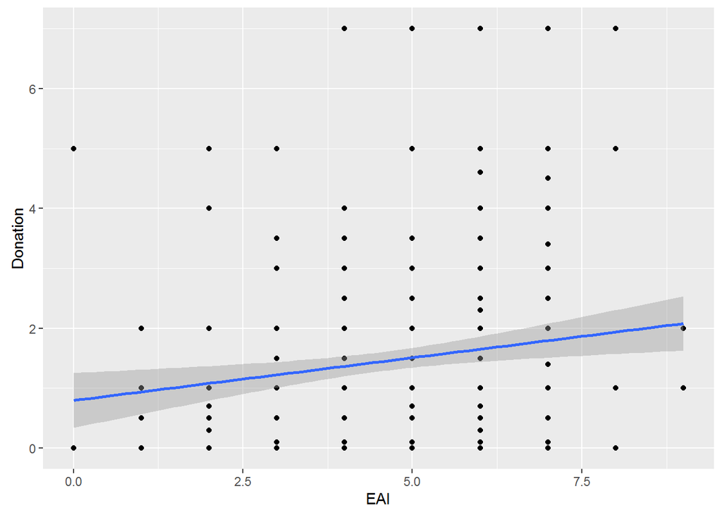

#### Donations by EAI score per treatment

Shows a point plot (not jittered) with Donation amount and the respective EAI score of each participant, for each treatment. Includes a linear regression line, including the 95% confidence region, of the EAI score as a predictor for the Donation amount, for each treatment.

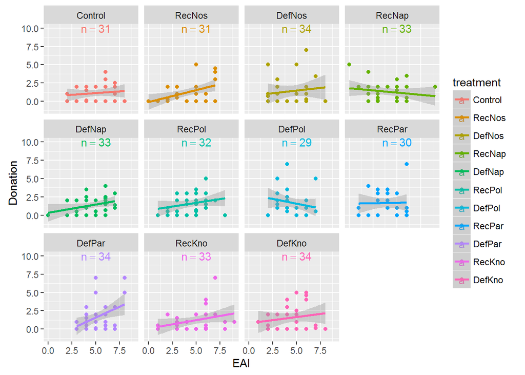

## 2. Variable: Donation dummy (1 if donated, 0 otherwise)

### Aggregated descriptive statistics

```r
summary(df$Donated)
```

```
## Not donated     Donated
##         109         245
```

### Distribution of donation dummy by treatment

```r
table(df$Donated, df$treatment)
```

```
##
##               Control RecNos DefNos RecNap DefNap RecPol DefPol RecPar
##   Not donated      13     11     16     10      9      7      5      8
##   Donated          18     20     18     23     24     25     24     22
##
##               DefPar RecKno DefKno
##   Not donated      8     10     12
##   Donated         26     23     22
```

### Decision to donate by treatment graph

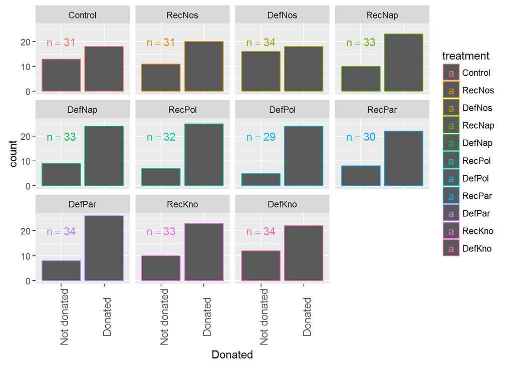

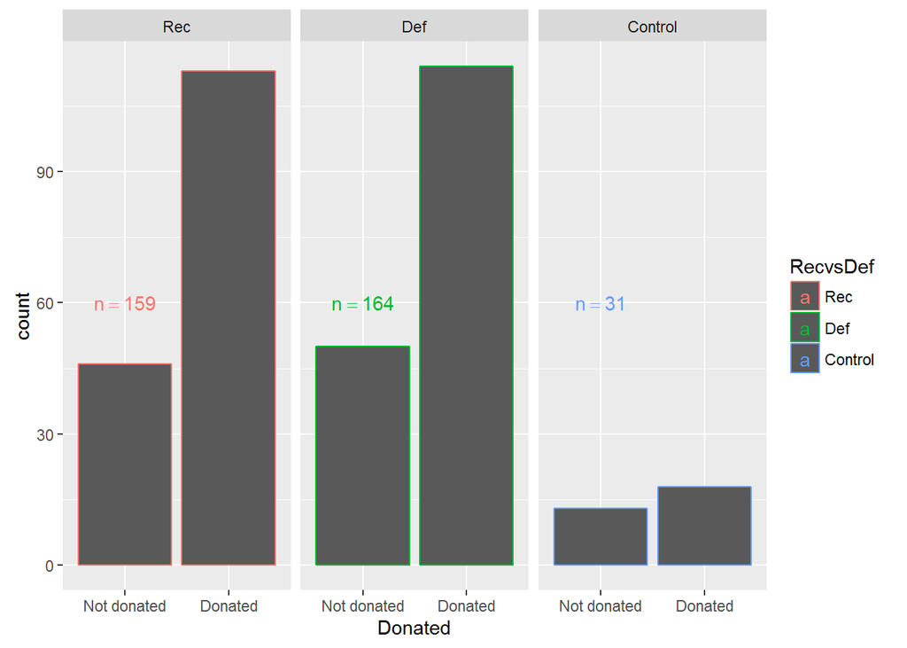

### Decision to donate by Reactance score

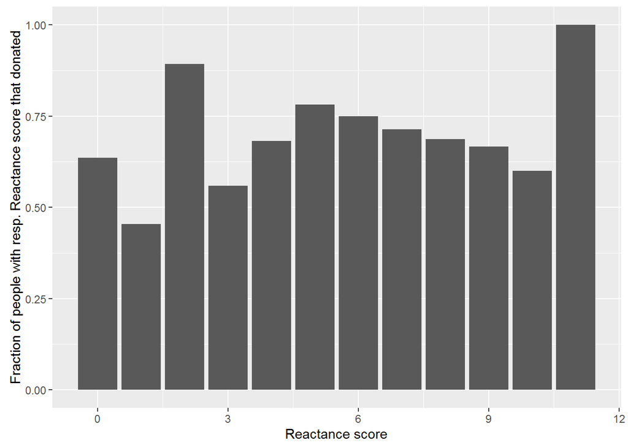

```r
chisq.test(table(df$Donated, df$Reactance), simulate.p.value = TRUE)
```

```
##
##  Pearson's Chi-squared test with simulated p-value (based on 2000
##  replicates)
##
## data:  table(df$Donated, df$Reactance)
## X-squared = 17.51, df = NA, p-value = 0.07646
```

```r
summary(glm(Donated ~ Reactance, df, family = "binomial"))
```

```
##
## Call:
## glm(formula = Donated ~ Reactance, family = "binomial", data = df)
##
## Deviance Residuals:
##     Min       1Q   Median       3Q      Max
## -1.6789  -1.4997   0.8253   0.8656   0.9500
##
## Coefficients:
##             Estimate Std. Error z value Pr(>|z|)
## (Intercept)  0.56154    0.27135   2.069   0.0385 *
## Reactance    0.05678    0.05676   1.000   0.3171
## ---
## Signif. codes:  0 '***' 0.001 '**' 0.01 '*' 0.05 '.' 0.1 ' ' 1
##
## (Dispersion parameter for binomial family taken to be 1)
##
##     Null deviance: 437.13  on 353  degrees of freedom
## Residual deviance: 436.12  on 352  degrees of freedom
## AIC: 440.12
##
## Number of Fisher Scoring iterations: 4
```

*The decision of whether or not to donate depends on Reactance (based on the ChiÂ² Test. However the test is only slightly significant (p < .1). The logistic regression model is not significant*

```
##
## Call:
## glm(formula = Donated ~ RecvsDefD * Sourcetype * Reactance, family = "binomial",
##     data = df)
##
## Deviance Residuals:
##     Min       1Q   Median       3Q      Max
## -2.0517  -1.2256   0.7042   0.8652   1.3754
##
## Coefficients:
##                                                 Estimate Std. Error
## (Intercept)                                      -2.2661     1.4148
## RecvsDefDDef                                      2.3394     1.5960
## SourcetypeNameAndPicture                          4.2609     1.7356
## SourcetypeKnowledgeable                           1.8156     1.7108
## SourcetypePolitical                               3.9211     1.7620
## SourcetypePartisan                                4.0801     1.8000
## Reactance                                         0.7068     0.3495
## RecvsDefDDef:SourcetypeNameAndPicture            -3.6135     2.0502
## RecvsDefDDef:SourcetypeKnowledgeable             -1.1643     2.0587
## RecvsDefDDef:SourcetypePolitical                 -4.2437     2.2493
## RecvsDefDDef:SourcetypePartisan                  -3.7545     2.2404
## RecvsDefDDef:Reactance                           -0.6970     0.3782
## SourcetypeNameAndPicture:Reactance               -0.9517     0.3972
## SourcetypeKnowledgeable:Reactance                -0.4263     0.4042
## SourcetypePolitical:Reactance                    -0.7910     0.4063
## SourcetypePartisan:Reactance                     -0.8928     0.4192
## RecvsDefDDef:SourcetypeNameAndPicture:Reactance   1.0061     0.4580
## RecvsDefDDef:SourcetypeKnowledgeable:Reactance    0.3912     0.4614
## RecvsDefDDef:SourcetypePolitical:Reactance        1.3030     0.5536
## RecvsDefDDef:SourcetypePartisan:Reactance         1.0556     0.5028
##                                                 z value Pr(>|z|)
## (Intercept)                                      -1.602   0.1092
## RecvsDefDDef                                      1.466   0.1427
## SourcetypeNameAndPicture                          2.455   0.0141 *
## SourcetypeKnowledgeable                           1.061   0.2886
## SourcetypePolitical                               2.225   0.0261 *
## SourcetypePartisan                                2.267   0.0234 *
## Reactance                                         2.022   0.0431 *
## RecvsDefDDef:SourcetypeNameAndPicture            -1.763   0.0780 .
```

[output cut: 8 more lines]

```
## RecvsDefDDef:SourcetypeNameAndPicture:Reactance   2.197   0.0280 *
## RecvsDefDDef:SourcetypeKnowledgeable:Reactance    0.848   0.3965
## RecvsDefDDef:SourcetypePolitical:Reactance        2.354   0.0186 *
## RecvsDefDDef:SourcetypePartisan:Reactance         2.099   0.0358 *
## ---
## Signif. codes:  0 '***' 0.001 '**' 0.01 '*' 0.05 '.' 0.1 ' ' 1
##
## (Dispersion parameter for binomial family taken to be 1)
##
##     Null deviance: 393.08  on 322  degrees of freedom
## Residual deviance: 368.68  on 303  degrees of freedom
##   (31 observations deleted due to missingness)
## AIC: 408.68
##
## Number of Fisher Scoring iterations: 5
```

```
##
## Call:
## glm(formula = Donated ~ RecvsDefD * NosvsSomeD * Reactance, family = "binomial",
##     data = df)
##
## Deviance Residuals:
##     Min       1Q   Median       3Q      Max
## -2.0517  -1.2256   0.7593   0.8170   1.2399
##
## Coefficients:
##                                              Estimate Std. Error z value
## (Intercept)                                   -2.2661     1.4146  -1.602
## RecvsDefDDef                                   2.3394     1.5959   1.466
## NosvsSomeDSome Source                          3.4557     1.4927   2.315
## Reactance                                      0.7068     0.3495   2.023
## RecvsDefDDef:NosvsSomeDSome Source            -2.8628     1.7281  -1.657
## RecvsDefDDef:Reactance                        -0.6970     0.3782  -1.843
## NosvsSomeDSome Source:Reactance               -0.7534     0.3619  -2.082
## RecvsDefDDef:NosvsSomeDSome Source:Reactance   0.8301     0.4020   2.065
##                                              Pr(>|z|)
## (Intercept)                                    0.1092
## RecvsDefDDef                                   0.1427
## NosvsSomeDSome Source                          0.0206 *
## Reactance                                      0.0431 *
## RecvsDefDDef:NosvsSomeDSome Source             0.0976 .
## RecvsDefDDef:Reactance                         0.0653 .
## NosvsSomeDSome Source:Reactance                0.0374 *
## RecvsDefDDef:NosvsSomeDSome Source:Reactance   0.0389 *
## ---
## Signif. codes:  0 '***' 0.001 '**' 0.01 '*' 0.05 '.' 0.1 ' ' 1
##
## (Dispersion parameter for binomial family taken to be 1)
##
##     Null deviance: 393.08  on 322  degrees of freedom
## Residual deviance: 379.73  on 315  degrees of freedom
##   (31 observations deleted due to missingness)
## AIC: 395.73
##
## Number of Fisher Scoring iterations: 4
```

### Decision to donate by Reactance score and treatment

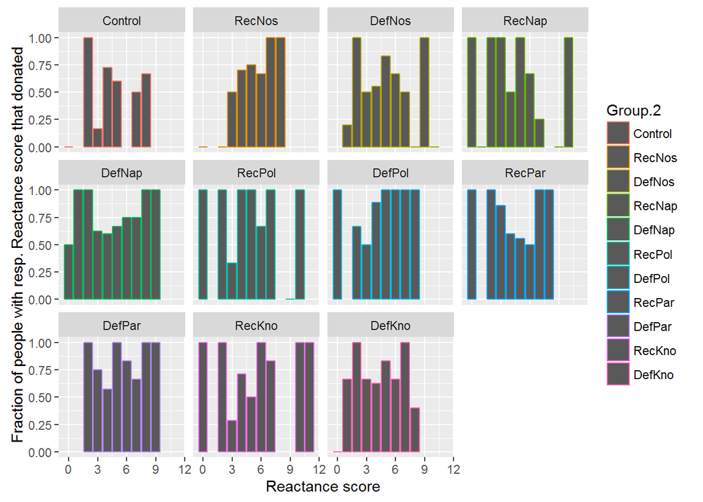

*At least visually there does not seem to be a relationship of Reactance score and Donation broken down by treatment.*

### Decision to donate by EAI score

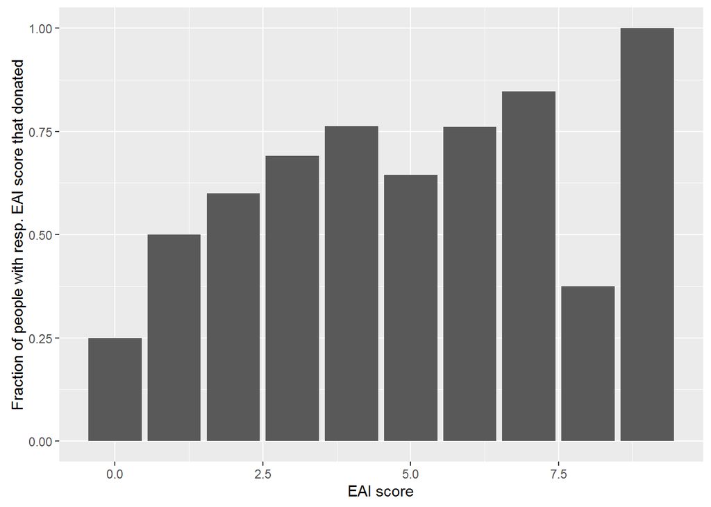

```r
chisq.test(table(df$Donated, df$EAI), simulate.p.value = TRUE)
```

```
##
##  Pearson's Chi-squared test with simulated p-value (based on 2000
##  replicates)
##
## data:  table(df$Donated, df$EAI)
## X-squared = 17.998, df = NA, p-value = 0.03248
```

*The ChiÂ²-test statistic (simulated p-value) is significant, indicating that the decision whether or not to donate anything does depend on the EAI.*

### Decision to donate by EAI score and treatment

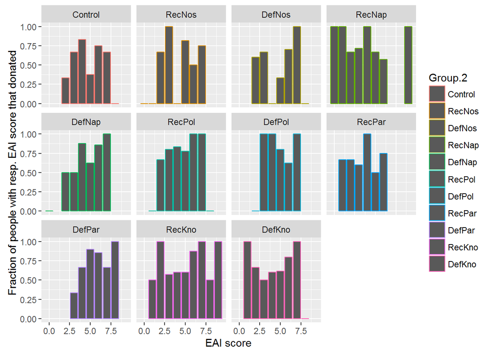

## 3. Variable: Beliefs about other participants donations

### Aggregated descriptive statistics

```r
summary(df$belief)
```

```
##    Min. 1st Qu.  Median    Mean 3rd Qu.    Max.
##   0.000   1.000   2.000   1.973   3.000   7.000
```

### Distribution of aggregated beliefs about donations

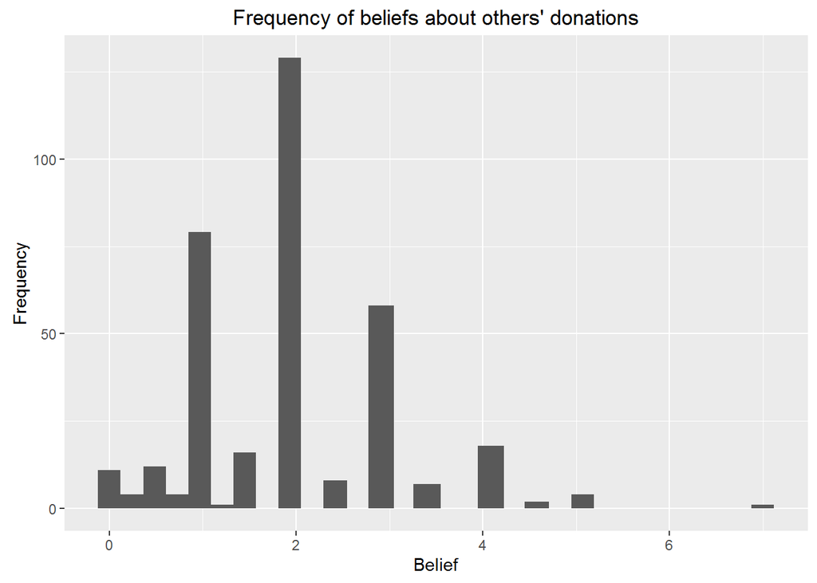

#### Distribution of beliefs by treatment

```
## group: Control
##   vars  n mean   sd median trimmed  mad min max range skew kurtosis   se
## 1    1 31 1.84 1.25      2    1.72 0.74   0   7     7  2.1     6.92 0.22
## --------------------------------------------------------
## group: RecNos
##   vars  n mean   sd median trimmed  mad min max range skew kurtosis   se
## 1    1 31 2.06 1.15      2    1.98 1.48   0   5     5 0.47    -0.28 0.21
## --------------------------------------------------------
## group: DefNos
##   vars  n mean   sd median trimmed  mad min max range skew kurtosis   se
## 1    1 34 1.58 1.07      2    1.55 1.48   0 4.5   4.5 0.43    -0.24 0.18
## --------------------------------------------------------
## group: RecNap
##   vars  n mean   sd median trimmed  mad min max range skew kurtosis   se
## 1    1 33 1.67 1.01      2     1.6 1.48   0   5     5 0.97     1.55 0.18
## --------------------------------------------------------
## group: DefNap
##   vars  n mean   sd median trimmed  mad min max range skew kurtosis   se
## 1    1 33 1.92 0.86      2    1.91 1.48 0.5   4   3.5 0.27    -0.62 0.15
## --------------------------------------------------------
## group: RecPol
##   vars  n mean   sd median trimmed  mad min max range skew kurtosis   se
## 1    1 32 2.11 0.92      2     2.1 1.48 0.5   4   3.5 0.02    -0.95 0.16
## --------------------------------------------------------
## group: DefPol
##   vars  n mean   sd median trimmed  mad min max range skew kurtosis   se
## 1    1 29 2.23 1.16      2    2.18 1.48 0.2   5   4.8 0.59    -0.45 0.21
## --------------------------------------------------------
## group: RecPar
##   vars  n mean   sd median trimmed  mad min max range skew kurtosis  se
## 1    1 30    2 1.07      2    1.92 1.48   0 4.5   4.5 0.46    -0.31 0.2
## --------------------------------------------------------
## group: DefPar
##   vars  n mean  sd median trimmed  mad min max range skew kurtosis   se
## 1    1 34 2.16 1.1      2    2.16 1.48   0   4     4 -0.1    -0.93 0.19
## --------------------------------------------------------
## group: RecKno
##   vars  n mean   sd median trimmed  mad min max range skew kurtosis   se
## 1    1 33 2.02 0.85      2       2 0.74 0.5   4   3.5 0.21    -0.64 0.15
## --------------------------------------------------------
## group: DefKno
##   vars  n mean   sd median trimmed  mad min max range skew kurtosis   se
## 1    1 34 2.16 1.09      2    2.05 1.48   1   5     4 0.82    -0.24 0.19
```

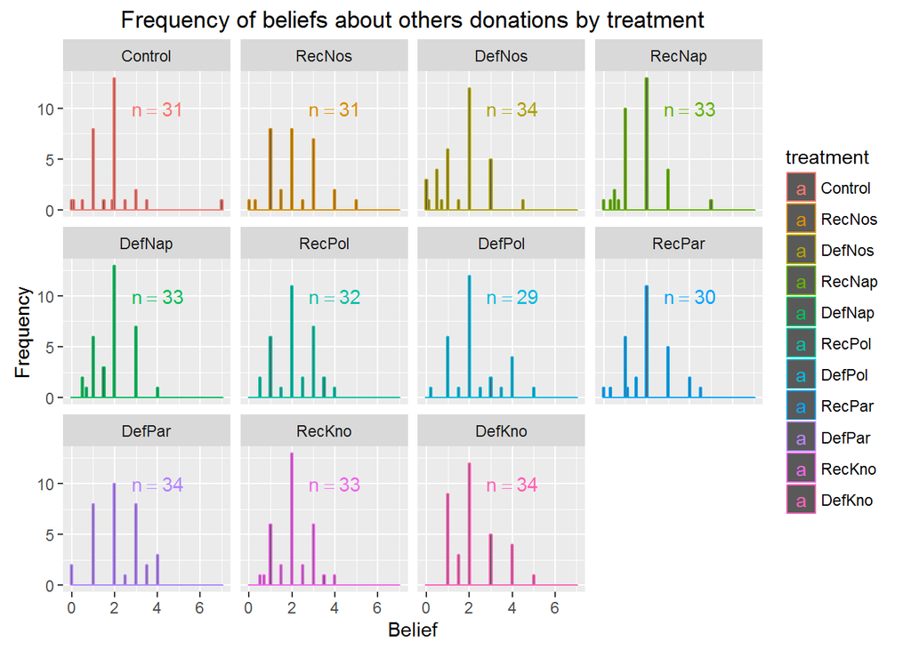

### Beliefs by treatment (Boxplot)

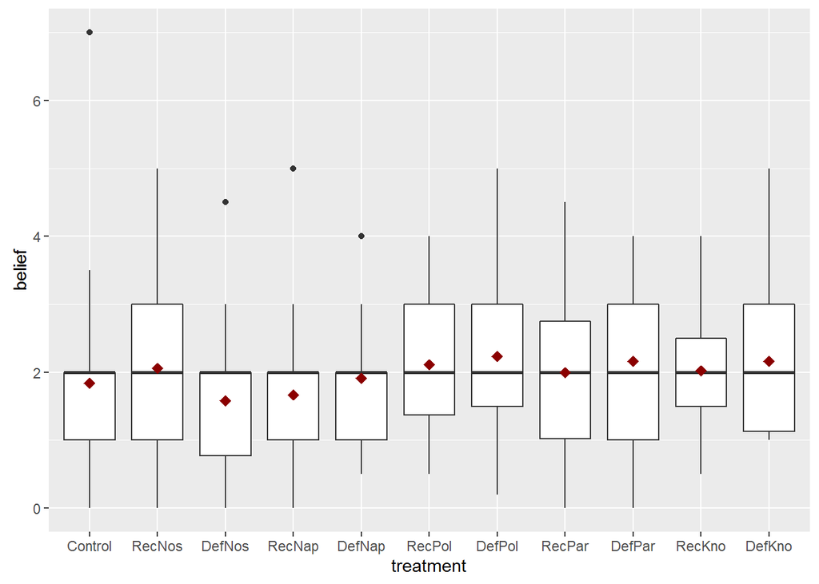

# Inferential Statistics

Following are relevant inferential statistics for each of three relevant dependent variables. These relevant dependent variables are 1. Donation, which is the amount the subject donated in order to retire emission rights 2. Donated, which is equal to 1 if the subject donated a positive amount, and 0 otherwise 3. Belief, which is the amount the subject thinks other participants in this experiment donated on average (not incentivized)

## 1. Variable: Donation to retire carbon licenses

### Kruskal-Wallis-Test

The following KW-test tests the null-hypothesis that the median donations in each treatment are the same. The test assumes variance homogeneity and equal distributions of donations in each treatment. It basically tests whether the distributions from the different treatments are shifted.

```r
kruskal.test(df$Donation ~ df$treatment)
```

```
##
##  Kruskal-Wallis rank sum test
##
## data:  df$Donation by df$treatment
## Kruskal-Wallis chi-squared = 7.434, df = 10, p-value = 0.6839
```

*We do not reject the null (p = .05).*

### ANOVA (one-way)

```r
summary(aov(df$Donation ~ df$treatment))
```

```
##               Df Sum Sq Mean Sq F value Pr(>F)
## df$treatment  10   13.5   1.345   0.557  0.849
## Residuals    343  828.6   2.416
```

*We do not reject the null (p = .05).*

## 2. Variable: Donation dummy (1 if donated, 0 otherwise)

### Chi? Test

The following Chi?-test tests the null-hypothesis that whether or not a participant decides to donate anything to retire emission rights (extensive margin) is independent of the treatments.

```r
table(df$Donated, df$treatment)
```

```
##
##               Control RecNos DefNos RecNap DefNap RecPol DefPol RecPar
##   Not donated      13     11     16     10      9      7      5      8
##   Donated          18     20     18     23     24     25     24     22
##
##               DefPar RecKno DefKno
##   Not donated      8     10     12
##   Donated         26     23     22
```

```r
chisq.test(table(df$Donated, df$treatment))
```

```
##
##  Pearson's Chi-squared test
##
## data:  table(df$Donated, df$treatment)
## X-squared = 11.645, df = 10, p-value = 0.3095
```

*We fail to reject the null (p = .05)*

## 3. Variable: Beliefs about other participants donations

### Kruskal-Wallis Test

The following KW-test tests the null-hypothesis that the median beliefs about other participants average donations in each treatment are the same. The test assumes variance homogeneity and equal distributions of donations in each treatment. It basically tests whether the distributions from the different treatments are shifted.

```r
kruskal.test(df$belief ~ df$treatment)
```

```
##
##  Kruskal-Wallis rank sum test
##
## data:  df$belief by df$treatment
## Kruskal-Wallis chi-squared = 14.128, df = 10, p-value = 0.1672
```

*We do not reject the null. The beliefs about other participants donation amounts do not differ significantly between the treatments.*

# Test of hypotheses from the working paper

## H0a

Mean and median payments to retire carbon licenses in the control condition are close to zero.

*H0: Average Donations = 0* *HA: Average Donations >< 0*

```r
t.test(df$Donation, mu = 0)
```

```
##
##  One Sample t-test
##
## data:  df$Donation
## t = 17.564, df = 353, p-value < 2.2e-16
## alternative hypothesis: true mean is not equal to 0
## 95 percent confidence interval:
##  1.280368 1.603248
## sample estimates:
## mean of x
##  1.441808
```

```r
wilcox.test(df$Donation, mu = 0)
```

```
##
##  Wilcoxon signed rank test with continuity correction
##
## data:  df$Donation
## V = 30135, p-value < 2.2e-16
## alternative hypothesis: true location is not equal to 0
```

*We reject the null that Donations are equal to 0*

## H0b

The share of subjects whose payments correspond to the recommended, respectively defaulted payment-value (convergence) is higher than in the control condition. Additionally, we expect that the share of subjects converging to the default is higher than the share converging to the recommendation.

### Aggregated donations in recommendation treatments > donations in control group

```r
describeBy(df$Donation, df$RecvsC)
```

```
## group: Control
##   vars  n mean   sd median trimmed  mad min max range skew kurtosis   se
## 1    1 31 1.13 1.15      1    1.02 1.48   0   4     4 0.42    -0.94 0.21
## --------------------------------------------------------
## group: Rec
##   vars   n mean   sd median trimmed  mad min max range skew kurtosis   se
## 1    1 159  1.4 1.42      1     1.2 1.48   0   7     7 1.24     1.89 0.11
```

```r
t.test(df$Donation ~ df$RecvsC)
```

```
##
##  Welch Two Sample t-test
##
## data:  df$Donation by df$RecvsC
## t = -1.1398, df = 49.594, p-value = 0.2598
## alternative hypothesis: true difference in means is not equal to 0
## 95 percent confidence interval:
##  -0.7413806  0.2046388
## sample estimates:
## mean in group Control     mean in group Rec
##              1.132258              1.400629
```

```r
wilcox.test(df$Donation ~ df$RecvsC)
```

```
##
##  Wilcoxon rank sum test with continuity correction
##
## data:  df$Donation by df$RecvsC
## W = 2244, p-value = 0.4199
## alternative hypothesis: true location shift is not equal to 0
```

*We cannot reject the null that Donations in recommendation treatments are equal to donations in control condition.*

### Aggregated donations in default treatments > donations in control group

```r
describeBy(df$Donation, df$DefvsC)
```

```
## group: Control
##   vars  n mean   sd median trimmed  mad min max range skew kurtosis   se
## 1    1 31 1.13 1.15      1    1.02 1.48   0   4     4 0.42    -0.94 0.21
## --------------------------------------------------------
## group: Def
##   vars   n mean   sd median trimmed  mad min max range skew kurtosis   se
## 1    1 164 1.54 1.71      1    1.23 1.48   0   7     7 1.38     1.56 0.13
```

```r
t.test(df$Donation ~ df$DefvsC)
```

```
##
##  Welch Two Sample t-test
##
## data:  df$Donation by df$DefvsC
## t = -1.6562, df = 58.519, p-value = 0.103
## alternative hypothesis: true difference in means is not equal to 0
## 95 percent confidence interval:
##  -0.90097966  0.08500798
## sample estimates:
## mean in group Control     mean in group Def
##              1.132258              1.540244
```

```r
wilcox.test(df$Donation ~ df$DefvsC)
```

```
##
##  Wilcoxon rank sum test with continuity correction
##
## data:  df$Donation by df$DefvsC
## W = 2289.5, p-value = 0.3698
## alternative hypothesis: true location shift is not equal to 0
```

*We cannot reject the null that Donations in default treatments are equal to donations in control condition.*

### Aggregated donations in default treatments > donations in recommendation treatments

```r
describeBy(df$Donation, df$RecvsDef)
```

```
## group: Rec
##   vars   n mean   sd median trimmed  mad min max range skew kurtosis   se
## 1    1 159  1.4 1.42      1     1.2 1.48   0   7     7 1.24     1.89 0.11
## --------------------------------------------------------
## group: Def
##   vars   n mean   sd median trimmed  mad min max range skew kurtosis   se
## 1    1 164 1.54 1.71      1    1.23 1.48   0   7     7 1.38     1.56 0.13
## --------------------------------------------------------
## group: Control
##   vars  n mean   sd median trimmed  mad min max range skew kurtosis   se
## 1    1 31 1.13 1.15      1    1.02 1.48   0   4     4 0.42    -0.94 0.21
```

```r
t.test(df$Donation[df$RecvsDef != "Control"] ~ df$RecvsDef[df$RecvsDef != "Control"])
```

```
##
##  Welch Two Sample t-test
##
## data:  df$Donation[df$RecvsDef != "Control"] by df$RecvsDef[df$RecvsDef != "Control"]
## t = -0.79821, df = 313.39, p-value = 0.4254
## alternative hypothesis: true difference in means is not equal to 0
## 95 percent confidence interval:
##  -0.4837626  0.2045326
## sample estimates:
## mean in group Rec mean in group Def
##          1.400629          1.540244
```

```r
# the above is the syntax alternative to Dummies, finally...
wilcox.test(df$Donation ~ df$RecvsDefD)
```

```
##
##  Wilcoxon rank sum test with continuity correction
##
## data:  df$Donation by df$RecvsDefD
## W = 12914, p-value = 0.8804
## alternative hypothesis: true location shift is not equal to 0
```

*We cannot reject the null that Donations in default treatments are equal to donations in recommendation treatments.*

## H0c

The share of subjects converging to the recommended, respectively defaulted payment-values in the name and picture condition is higher than in the neutral source-condition.

### For Recommendations: Donations in Name and Picture treatments > Donations in No-Source treatments

```r
describeBy(df$Donation, df$RecNapvsRecNos)
```

```
## group: RecNap
##   vars  n mean   sd median trimmed  mad min max range skew kurtosis   se
## 1    1 33 1.32 1.31      1    1.15 1.48   0   5     5 0.83     0.13 0.23
## --------------------------------------------------------
## group: RecNos
##   vars  n mean   sd median trimmed  mad min max range skew kurtosis   se
## 1    1 31 1.24 1.39      1    0.99 1.48   0   5     5 1.14     0.52 0.25
```

```r
t.test(df$Donation ~ df$RecNapvsRecNos)
```

```
##
##  Welch Two Sample t-test
##
## data:  df$Donation by df$RecNapvsRecNos
## t = 0.25345, df = 61.007, p-value = 0.8008
## alternative hypothesis: true difference in means is not equal to 0
## 95 percent confidence interval:
##  -0.5906449  0.7621014
## sample estimates:
## mean in group RecNap mean in group RecNos
##             1.321212             1.235484
```

```r
wilcox.test(df$Donation ~ df$RecNapvsRecNos)
```

```
##
##  Wilcoxon rank sum test with continuity correction
##
## data:  df$Donation by df$RecNapvsRecNos
## W = 546, p-value = 0.6373
## alternative hypothesis: true location shift is not equal to 0
```

*We cannot reject the null that Donations in recommendation treatments informing about the name and picture of the source are equal to donations in recommendation treatments providing no information about the source of the recommendation.*

### For Defaults: Donations in Name and Picture treatments > Donations in No-Source treatments

```r
describeBy(df$Donation, df$DefNapvsDefNos)
```

```
## group: DefNap
##   vars  n mean   sd median trimmed  mad min max range skew kurtosis  se
## 1    1 33 1.38 1.13    1.5    1.29 1.19   0   4     4 0.27    -0.88 0.2
## --------------------------------------------------------
## group: DefNos
##   vars  n mean   sd median trimmed  mad min max range skew kurtosis   se
## 1    1 34 1.42 2.08    0.5    1.05 0.74   0   7     7 1.46     0.93 0.36
```

```r
t.test(df$Donation ~ df$DefNapvsDefNos)
```

```
##
##  Welch Two Sample t-test
##
## data:  df$Donation by df$DefNapvsDefNos
## t = -0.11715, df = 51.157, p-value = 0.9072
## alternative hypothesis: true difference in means is not equal to 0
## 95 percent confidence interval:
##  -0.8663619  0.7708183
## sample estimates:
## mean in group DefNap mean in group DefNos
##             1.375758             1.423529
```

```r
wilcox.test(df$Donation ~ df$DefNapvsDefNos)
```

```
##
##  Wilcoxon rank sum test with continuity correction
##
## data:  df$Donation by df$DefNapvsDefNos
## W = 656, p-value = 0.2211
## alternative hypothesis: true location shift is not equal to 0
```

*We cannot reject the null that Donations in default treatments informing about the name and picture of the source are equal to donations in default treatments providing no information about the source of the default.*

## H1

A subject’s reaction towards the respective intervention depends on is predicted by trait reactance.

*The following are not rigurous tests of the respective hypotheses, but rather approaches to get an idea about relationships and predictions.*

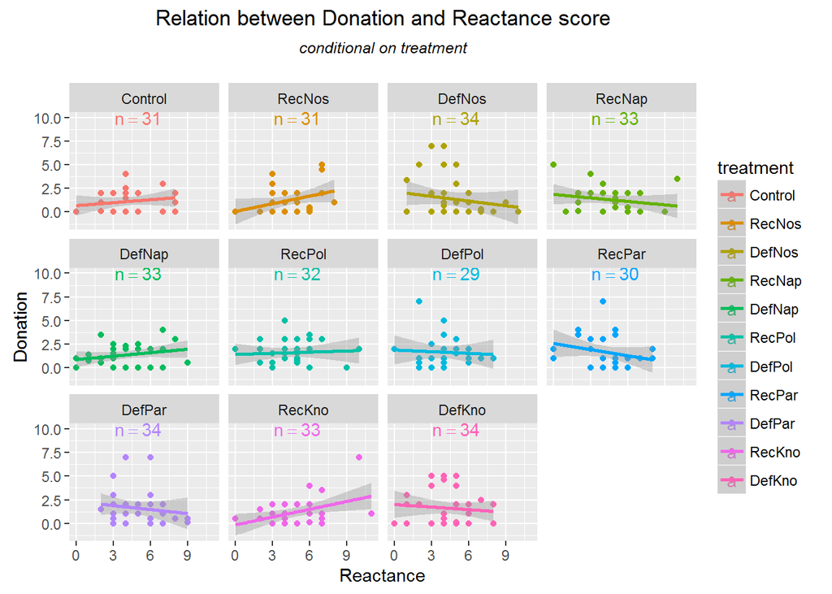

### H1a

A subject that scores high on trait reactance is less likely to converge to the recommended and defaulted payment-values, than a subject scoring low on trait reactance. *The following treats the Reactance score as metric.*

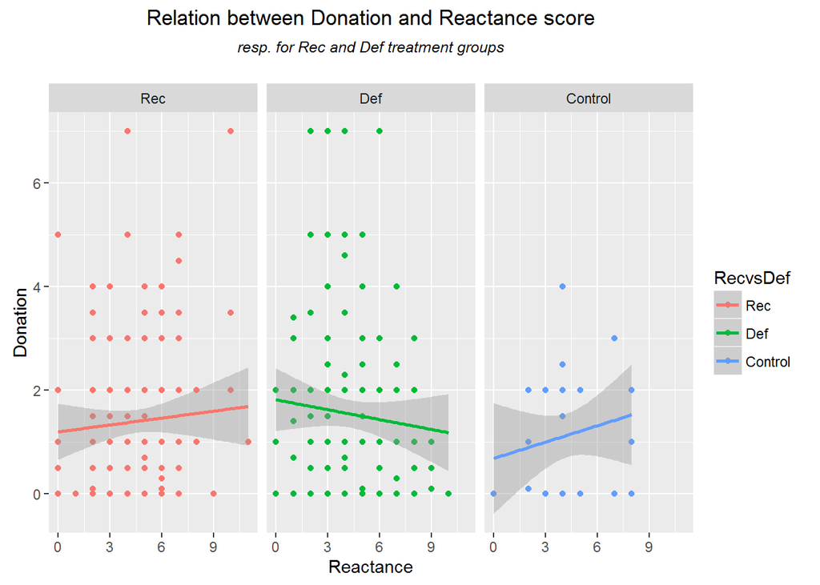

### H1b

A subject that scores high on trait reactance is less likely to converge to the defaulted than to the recommended payment-value.

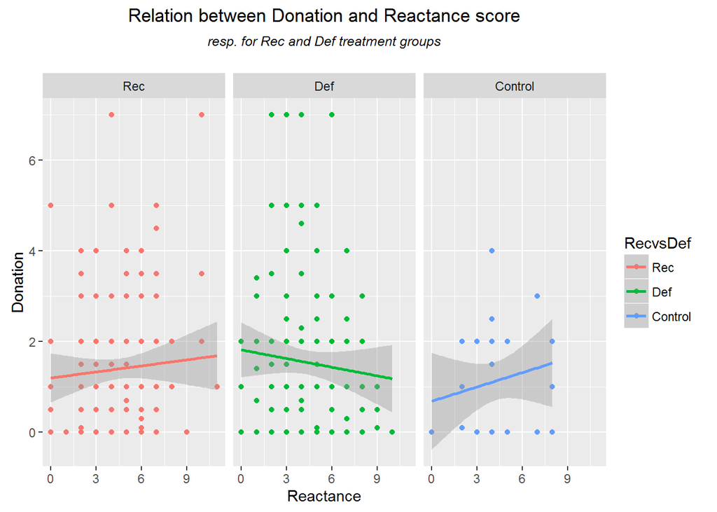

*Left is recommendation group, middle is default group, right is Control.*

## H2

The share of subjects converging to the recommended, respectively defaulted payment-values in the condition informing about the academic degree of the source is higher than in the name and picture condition.

### For Recommendations: Donations in Knowledge treatments > Donations in Name and Picture treatments

```r
describeBy(df$Donation, df$RecNapvsRecKno)
```

```
## group: RecNap
##   vars  n mean   sd median trimmed  mad min max range skew kurtosis   se
## 1    1 33 1.32 1.31      1    1.15 1.48   0   5     5 0.83     0.13 0.23
## --------------------------------------------------------
## group: RecKno
##   vars  n mean   sd median trimmed  mad min max range skew kurtosis   se
## 1    1 33 1.18 1.47      1    0.91 1.48   0   7     7 2.06     5.17 0.26
```

```r
t.test(df$Donation ~ df$RecNapvsRecKno)
```

```
##
##  Welch Two Sample t-test
##
## data:  df$Donation by df$RecNapvsRecKno
## t = 0.3982, df = 63.131, p-value = 0.6918
## alternative hypothesis: true difference in means is not equal to 0
## 95 percent confidence interval:
##  -0.5479357  0.8206629
## sample estimates:
## mean in group RecNap mean in group RecKno
##             1.321212             1.184848
```

```r
wilcox.test(df$Donation ~ df$RecNapvsRecKno)
```

```
##
##  Wilcoxon rank sum test with continuity correction
##
## data:  df$Donation by df$RecNapvsRecKno
## W = 593, p-value = 0.5271
## alternative hypothesis: true location shift is not equal to 0
```

### For Defaults: Donations in Knowledge treatments > Donations in Name and Picture treatments

```r
describeBy(df$Donation, df$DefNapvsDefKno)
```

```
## group: DefNap
##   vars  n mean   sd median trimmed  mad min max range skew kurtosis  se
## 1    1 33 1.38 1.13    1.5    1.29 1.19   0   4     4 0.27    -0.88 0.2
## --------------------------------------------------------
## group: DefKno
##   vars  n mean  sd median trimmed  mad min max range skew kurtosis   se
## 1    1 34 1.59 1.7    1.5     1.4 2.22   0   5     5 0.73    -0.74 0.29
```

```r
t.test(df$Donation ~ df$DefNapvsDefKno)
```

```
##
##  Welch Two Sample t-test
##
## data:  df$Donation by df$DefNapvsDefKno
## t = -0.62073, df = 57.523, p-value = 0.5372
## alternative hypothesis: true difference in means is not equal to 0
## 95 percent confidence interval:
##  -0.9226528  0.4859326
## sample estimates:
## mean in group DefNap mean in group DefKno
##             1.375758             1.594118
```

```r
wilcox.test(df$Donation ~ df$DefNapvsDefKno)
```

```
##
##  Wilcoxon rank sum test with continuity correction
##
## data:  df$Donation by df$DefNapvsDefKno
## W = 557.5, p-value = 0.9691
## alternative hypothesis: true location shift is not equal to 0
```

## H3-1

The share of subjects converging to the recommended, respectively defaulted payment-values in the condition informing about the political characteristic of the source is lower than in the name and picture condition.

### For Recommendations: Donations in Political treatments < Donations in Name and Picture treatments

```r
describeBy(df$Donation, df$RecNapvsRecPol)
```

```
## group: RecNap
##   vars  n mean   sd median trimmed  mad min max range skew kurtosis   se
## 1    1 33 1.32 1.31      1    1.15 1.48   0   5     5 0.83     0.13 0.23
## --------------------------------------------------------
## group: RecPol
##   vars  n mean   sd median trimmed  mad min max range skew kurtosis   se
## 1    1 32  1.6 1.29   1.75    1.53 1.85   0   5     5 0.43    -0.48 0.23
```

```r
t.test(df$Donation ~ df$RecNapvsRecPol)
```

```
##
##  Welch Two Sample t-test
##
## data:  df$Donation by df$RecNapvsRecPol
## t = -0.86661, df = 62.985, p-value = 0.3894
## alternative hypothesis: true difference in means is not equal to 0
## 95 percent confidence interval:
##  -0.9216563  0.3640806
## sample estimates:
## mean in group RecNap mean in group RecPol
##             1.321212             1.600000
```

```r
wilcox.test(df$Donation ~ df$RecNapvsRecPol)
```

```
##
##  Wilcoxon rank sum test with continuity correction
##
## data:  df$Donation by df$RecNapvsRecPol
## W = 458, p-value = 0.3506
## alternative hypothesis: true location shift is not equal to 0
```

*We cannot reject the null that Donations in recommendation treatments informing about the political mandate of the source are equal to donations in recommendations treatments providing the name and picture of the source.*

### For Defaults: Donations in Political treatments < Donations in Name and Picture treatments

```r
describeBy(df$Donation, df$DefNapvsDefPol)
```

```
## group: DefNap
##   vars  n mean   sd median trimmed  mad min max range skew kurtosis  se
## 1    1 33 1.38 1.13    1.5    1.29 1.19   0   4     4 0.27    -0.88 0.2
## --------------------------------------------------------
## group: DefPol
##   vars  n mean   sd median trimmed  mad min max range skew kurtosis   se
## 1    1 29 1.66 1.68      1    1.44 1.48   0   7     7 1.51     1.87 0.31
```

```r
t.test(df$Donation ~ df$DefNapvsDefPol)
```

```
##
##  Welch Two Sample t-test
##
## data:  df$Donation by df$DefNapvsDefPol
## t = -0.75775, df = 48.01, p-value = 0.4523
## alternative hypothesis: true difference in means is not equal to 0
## 95 percent confidence interval:
##  -1.0208211  0.4619914
## sample estimates:
## mean in group DefNap mean in group DefPol
##             1.375758             1.655172
```

```r
wilcox.test(df$Donation ~ df$DefNapvsDefPol)
```

```
##
##  Wilcoxon rank sum test with continuity correction
##
## data:  df$Donation by df$DefNapvsDefPol
## W = 466.5, p-value = 0.8689
## alternative hypothesis: true location shift is not equal to 0
```

*We cannot reject the null that donations in default treatments informing about the political mandate of the source are equal to donations in default treatments providing the name and picture of the source.*

## H3-2

When the source is political the share of subjects converging to the default is lower than the share of subjects converging to the recommendation.

### Donations in default treatments informing about the political characteristics of the source < donations in recommendation treatments informing about the political characteristics of the source

```r
describeBy(df$Donation, df$RecPolvsDefPol)
```

```
## group: RecPol
##   vars  n mean   sd median trimmed  mad min max range skew kurtosis   se
## 1    1 32  1.6 1.29   1.75    1.53 1.85   0   5     5 0.43    -0.48 0.23
## --------------------------------------------------------
## group: DefPol
##   vars  n mean   sd median trimmed  mad min max range skew kurtosis   se
## 1    1 29 1.66 1.68      1    1.44 1.48   0   7     7 1.51     1.87 0.31
```

```r
t.test(df$Donation ~ df$RecPolvsDefPol)
```

```
##
##  Welch Two Sample t-test
##
## data:  df$Donation by df$RecPolvsDefPol
## t = -0.14289, df = 52.32, p-value = 0.8869
## alternative hypothesis: true difference in means is not equal to 0
## 95 percent confidence interval:
##  -0.8298648  0.7195200
## sample estimates:
## mean in group RecPol mean in group DefPol
##             1.600000             1.655172
```

```r
wilcox.test(df$Donation ~ df$RecPolvsDefPol)
```

```
##
##  Wilcoxon rank sum test with continuity correction
##
## data:  df$Donation by df$RecPolvsDefPol
## W = 486, p-value = 0.7531
## alternative hypothesis: true location shift is not equal to 0
```

*We cannot reject the null that donations in default treatments informing about the political characteristics of the source are equal to donations in recommendation treatments informing about the political characteristics of the source.*

### H3a (HERE ALSO INCLUDE PARTY TREATMENTS, NOT JUST POLITICAL?)

A subject that scores high on trust in politics is more likely to converge to the recommended and defaulted payment-values, than a subject scoring low on trust in politics. *In treatments informing about the political characteristics of the source.*

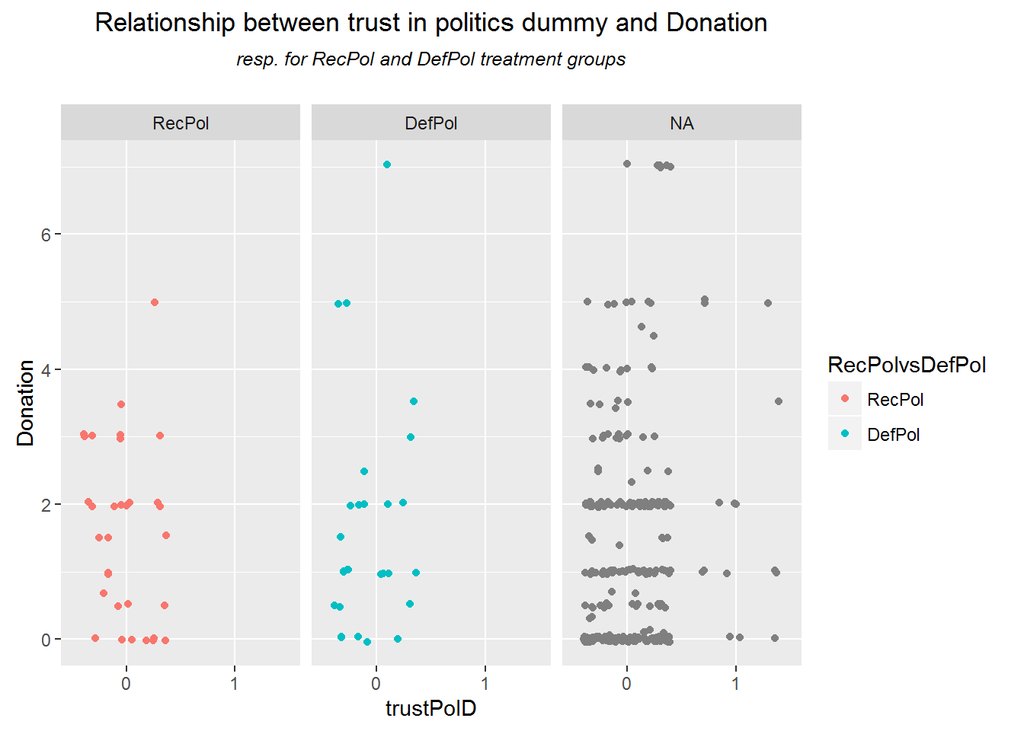

```
##
##  Wilcoxon rank sum test with continuity correction
##
## data:  df$Donation by df$trustPolD
## W = 2104, p-value = 0.2474
## alternative hypothesis: true location shift is not equal to 0
```

*Problem is that there are not enough observations with high trust in politics (no observation in Default x Political treatment.*

### H3b

A subject that values conformity, i.e. doing what the majority does, is more likely to converge to the recommended and defaulted payment-values, than a subject that does not value conformity.

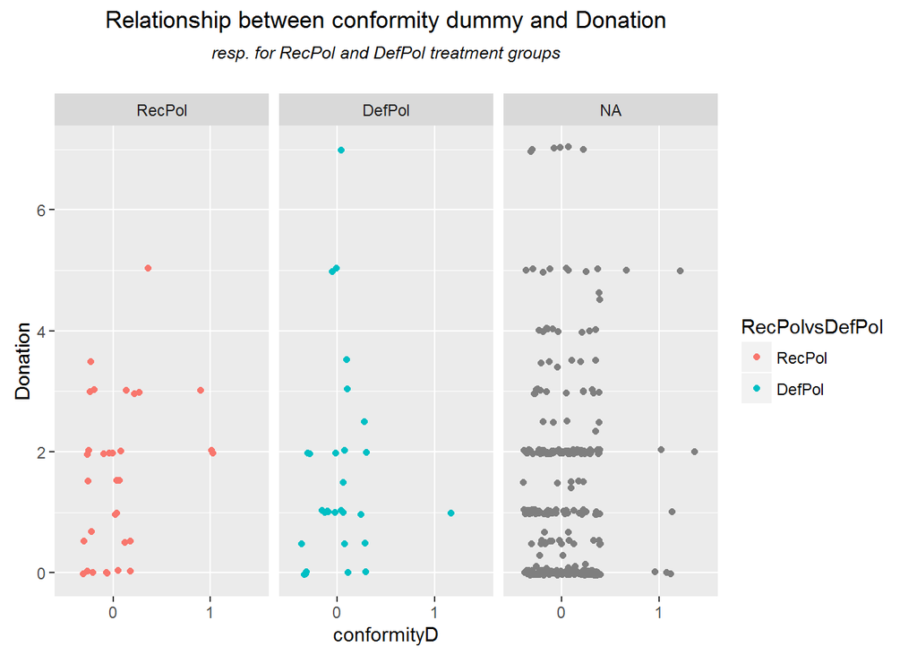

```
##
##  Wilcoxon rank sum test with continuity correction
##
## data:  df$Donation by df$conformityD
## W = 1696, p-value = 0.2961
## alternative hypothesis: true location shift is not equal to 0
```

## H4

The share of subjects converging to the recommended, respectively defaulted payment-values, relative to the political-characteristic condition, is higher for subjects with same party preferences, and lower for subjects with different party preferences. **Hypothesis is possibly phrased wrongly.**

```r
table(df$party)
```

```
##
##                 AfD              Andere     Bündnis90/Grüne
##                   9                  21                  71
##             CDU/CSU           Die Linke                 FDP
##                  58                  65                  11
## Keine (Nichtwähler)        Keine Angabe                 SPD
##                  44                   7                  68
```

```r
table(df$party, df$treatment)
```

```
##
##                       Control RecNos DefNos RecNap DefNap RecPol DefPol
##   AfD                       2      1      0      2      0      0      1
##   Andere                    2      3      1      3      1      1      1
##   Bündnis90/Grüne           6      6      7      8      7      7      5
##   CDU/CSU                   5      7      4      2      5      4      5
##   Die Linke                 7      4      6      5      8      8      5
##   FDP                       0      1      2      1      1      0      0
##   Keine (Nichtwähler)       5      5      6      3      2      2      3
##   Keine Angabe              1      0      3      0      0      0      2
##   SPD                       3      4      5      9      9     10      7
##
##                       RecPar DefPar RecKno DefKno
##   AfD                      0      0      1      2
##   Andere                   2      1      3      3
##   Bündnis90/Grüne          2     11      5      7
##   CDU/CSU                  6      7     10      3
##   Die Linke                7      5      6      4
##   FDP                      0      0      3      3
##   Keine (Nichtwähler)      7      5      3      3
##   Keine Angabe             1      0      0      0
##   SPD                      5      5      2      9
```

```r
chisq.test(table(df$party, df$treatment))
```

```
##
##  Pearson's Chi-squared test
##
## data:  table(df$party, df$treatment)
## X-squared = 82.373, df = 80, p-value = 0.4058
```

```
##
##             Control RecNos DefNos RecNap DefNap RecPol DefPol RecPar
##   Not green      25     25     27     25     26     25     24     28
##   Green           6      6      7      8      7      7      5      2
##
##             DefPar RecKno DefKno
##   Not green     23     28     27
##   Green         11      5      7
```

```
##
##             RecPar DefPar
##   Not green     28     23
##   Green          2     11
```

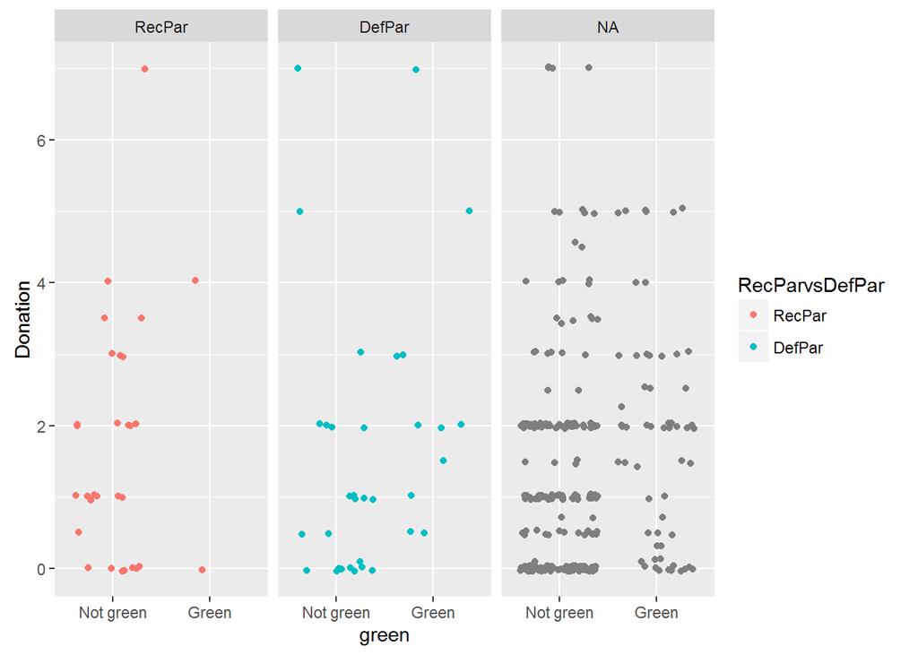

# Further Statistics and Tests

## Compare observations that believe we cooperated with Julia Verlinden vs. those who don’t

### Variable: Donation amount

```
## group: Ja
##   vars   n mean   sd median trimmed  mad min max range skew kurtosis  se
## 1    1 153 1.32 1.27      1    1.16 1.48   0   5     5 0.88     0.23 0.1
## --------------------------------------------------------
## group: Nein
##   vars   n mean   sd median trimmed  mad min max range skew kurtosis   se
## 1    1 109 1.73 1.79    1.5    1.45 1.48   0   7     7  1.3     1.38 0.17
```

```
##
##  Welch Two Sample t-test
##
## data:  df$Donation by df$believe2
## t = -2.0378, df = 182.44, p-value = 0.04301
## alternative hypothesis: true difference in means is not equal to 0
## 95 percent confidence interval:
##  -0.80107778 -0.01294152
## sample estimates:
##   mean in group Ja mean in group Nein
##           1.324183           1.731193
```

```
##
##  Wilcoxon rank sum test with continuity correction
##
## data:  df$Donation by df$believe2
## W = 7631.5, p-value = 0.2333
## alternative hypothesis: true location shift is not equal to 0
```

*Participants who believe we cooperated with Julia Verlinden have a **lower** mean Donation, and also a **lower** variance. The difference is significant (p < .1) judged by the Welch Two Sample t-test, but insignificant judged by the Wilcoxon-Mann-Whitney-U test.*

### Variable: Decision to donate

```
##
##                Ja Nein
##   Not donated  41   30
##   Donated     112   79
```

```r
chisq.test(table(df$Donated, df$believe2))
```

```
##
##  Pearson's Chi-squared test with Yates' continuity correction
##
## data:  table(df$Donated, df$believe2)
## X-squared = 5.7642e-31, df = 1, p-value = 1
```

*The Chi?-Test is not significant. This implies that the decision whether or not to contribute anything vs. nothing is not dependent on the answer to the question whether the respondent believed that we really cooperated with Julia Verlinden.*

## Decision to donate for subjects seeing a recommendation vs. subjects seeing a default, irrespective of source

```r
table(df$Donated, df$RecvsDef)
```

```
##
##               Rec Def Control
##   Not donated  46  50      13
##   Donated     113 114      18
```

```r
chisq.test(table(df$Donated, df$RecvsDef))
```

```
##
##  Pearson's Chi-squared test
##
## data:  table(df$Donated, df$RecvsDef)
## X-squared = 2.072, df = 2, p-value = 0.3549
```

*The Chi?-Test is not significant. This implies that the decision whether or not to contribute anything vs. nothing is not dependent on whether the subjects encountered a recommendation or a default value with our without any specific source or information on the source (or nothing at all, as in the control group).*

## Decision to donate for subjects seeing a recommendation vs. subjects seeing a default, with non-political source-information

```
##
##               Non-political/partisan Rec Non-political/partisan Def
##   Not donated                         31                         37
##   Donated                             66                         64
```

```
##
##  Pearson's Chi-squared test with Yates' continuity correction
##
## data:  table(df$Donated, df$RecvsDefNonPolPar)
## X-squared = 0.29465, df = 1, p-value = 0.5873
```

*The Chi?-Test is not significant. This implies that the decision whether or not to contribute anything vs. nothing is not dependent on whether the subjects encountered a non-political or non-partisan recommendation or a respective default value.*

## Decision to donate for subjects seeing an intervention without source-information vs. some source-information

```
##
##               No Source Some Source Control
##   Not donated        27          69      13
##   Donated            38         189      18
```

```
##
##  Pearson's Chi-squared test
##
## data:  table(df$Donated, df$NosvsSome)
## X-squared = 7.3127, df = 2, p-value = 0.02583
```

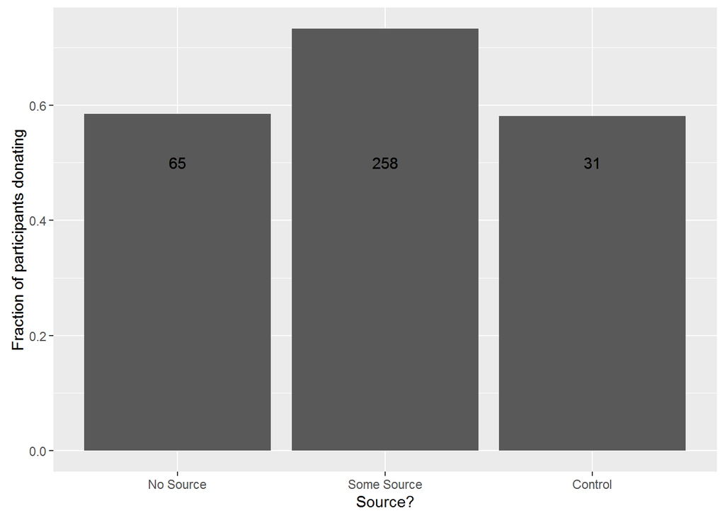

```
##
## Call:
## glm(formula = Donated ~ NosvsSome, family = "binomial", data = df)
##
## Deviance Residuals:
##     Min       1Q   Median       3Q      Max
## -1.6241  -1.3256   0.7889   0.7889   1.0427
##
## Coefficients:
##                      Estimate Std. Error z value Pr(>|z|)
## (Intercept)           0.34175    0.25170   1.358   0.1745
## NosvsSomeSome Source  0.66589    0.28833   2.309   0.0209 *
## NosvsSomeControl     -0.01633    0.44253  -0.037   0.9706
## ---
## Signif. codes:  0 '***' 0.001 '**' 0.01 '*' 0.05 '.' 0.1 ' ' 1
##
## (Dispersion parameter for binomial family taken to be 1)
##
##     Null deviance: 437.13  on 353  degrees of freedom
## Residual deviance: 430.04  on 351  degrees of freedom
## AIC: 436.04
##
## Number of Fisher Scoring iterations: 4
```

*The Chi? test is significant (p < .1). This implies that the decision whether or not to contribute or not depends on whether or not some source-information vs. no source-information is provided.* *In the logit regression, the estimator for the provision of any source-information is also statistically significant.*

### Further investigation of this effect: Variation by type of intervention?

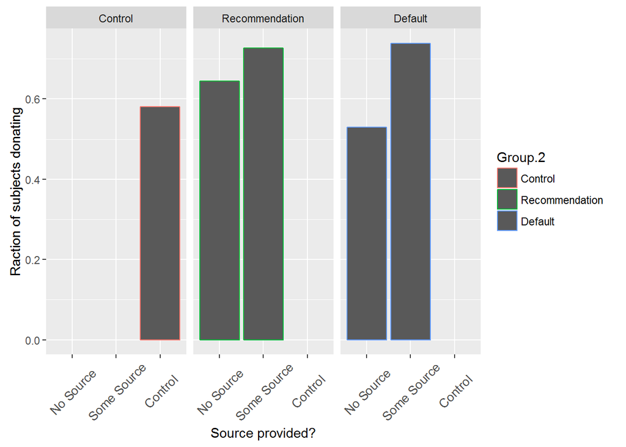

```
##
## Call:
## glm(formula = Donated ~ Sourcetype * RecvsDefD, family = "binomial",
##     data = df)
##
## Deviance Residuals:
##     Min       1Q   Median       3Q      Max
## -1.8750  -1.2278   0.7325   0.8497   1.1278
##
## Coefficients:
##                                       Estimate Std. Error z value Pr(>|z|)
## (Intercept)                             0.5978     0.3754   1.593    0.111
## SourcetypeNameAndPicture                0.2351     0.5333   0.441    0.659
## SourcetypeKnowledgeable                 0.2351     0.5333   0.441    0.659
## SourcetypePolitical                     0.6751     0.5690   1.187    0.235
## SourcetypePartisan                      0.4138     0.5580   0.742    0.458
## RecvsDefDDef                           -0.4801     0.5089  -0.943    0.346
## SourcetypeNameAndPicture:RecvsDefDDef   0.6280     0.7451   0.843    0.399
## SourcetypeKnowledgeable:RecvsDefDDef    0.2533     0.7289   0.348    0.728
## SourcetypePolitical:RecvsDefDDef        0.7757     0.8267   0.938    0.348
## SourcetypePartisan:RecvsDefDDef         0.6471     0.7700   0.840    0.401
##
## (Dispersion parameter for binomial family taken to be 1)
##
##     Null deviance: 393.08  on 322  degrees of freedom
## Residual deviance: 383.31  on 313  degrees of freedom
##   (31 observations deleted due to missingness)
## AIC: 403.31
##
## Number of Fisher Scoring iterations: 4
```

```
##
## Call:
## glm(formula = Donated ~ NosvsSomeD * RecvsDefD, family = "binomial",
##     data = df)
##
## Deviance Residuals:
##     Min       1Q   Median       3Q      Max
## -1.6378  -1.2278   0.7787   0.7993   1.1278
##
## Coefficients:
##                                    Estimate Std. Error z value Pr(>|z|)
## (Intercept)                          0.5978     0.3754   1.593    0.111
## NosvsSomeDSome Source                0.3794     0.4245   0.894    0.371
## RecvsDefDDef                        -0.4801     0.5089  -0.943    0.346
## NosvsSomeDSome Source:RecvsDefDDef   0.5408     0.5815   0.930    0.352
##
## (Dispersion parameter for binomial family taken to be 1)
##
##     Null deviance: 393.08  on 322  degrees of freedom
## Residual deviance: 386.93  on 319  degrees of freedom
##   (31 observations deleted due to missingness)
## AIC: 394.93
##
## Number of Fisher Scoring iterations: 4
```